# Assignment 4: Global Health

Author

Maeve Grady and Leanne Chook

## Introduction

For this assignment, we decided to focus on global health, in particular, primary healthcare and non-communicable diseases. A leading cause of death around the world has been due to non-communicable diseases, which are also known as “silent” diseases that are caused by lifestyle choices, and are easily preventable with well-resourced and robust primary healthcare infrastructure.

We wanted to use these data visualizations to explore if better policy is needed to increase government spending on primary healthcare and what are some areas that the spending should be focused on.

## Loading the Necessary Libraries

```r
library(tidyverse)
library(readxl)
library(sf)
library(tigris)
library(rgeoboundaries)
library(readr)
library(ggrepel)
library(janitor)
library(rgeoboundaries)
library(sf)
```

## Visualization 1: Scatterplot of Primary Health Expenditures and GDP per Capita

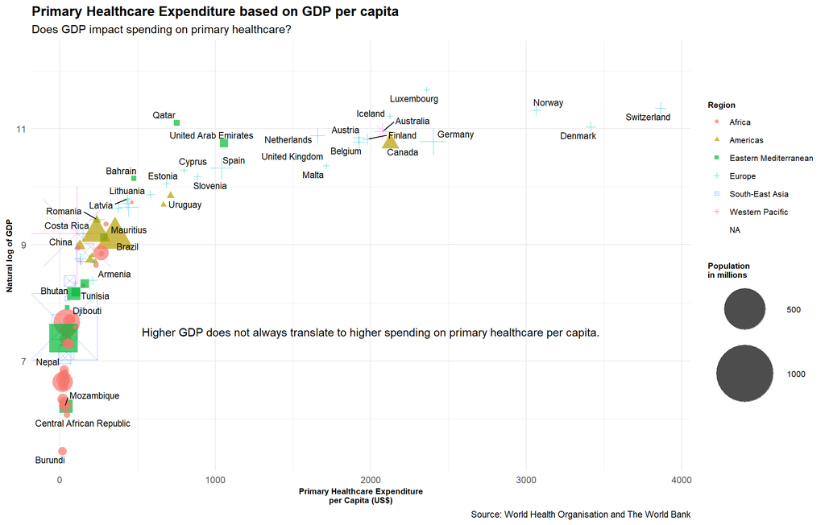

```r
options(scipen = 999)

# read in the datasets

health_expenditures <- read_excel("nha_indicators.xlsx")
gdppc <- read_excel("gdp.xls")
region_data <- read_csv("alcohol.csv")

# make the expenditures dataset wider
expenditures_wide <- health_expenditures %>%
  select(Countries, Indicators, '2018')

expenditures_wide <- pivot_wider(data = health_expenditures,
                                 id_cols = Countries,
                                 names_from = Indicators,
                                 values_from = '2018'
)

# select only relevant columns
gdppc2018 <- gdppc %>%
  select(Countries, '2018') %>%
  rename("gdp" = '2018')

region_data <- region_data %>%
  select(Location, ParentLocation) %>%
  rename("Countries" = Location,
         "region" = ParentLocation)

# merge the datasets
expenditures <- merge(expenditures_wide, gdppc2018,
                      by = 'Countries',
                      all.x = TRUE,
                      all.y = TRUE)

expenditures <- merge(expenditures, region_data,
                      by = 'Countries',
                      all.x = TRUE,
                      all.y = TRUE)

# remove duplicate rows
expenditures <- expenditures %>% distinct()

# rename variables for ease of coding
expenditures <- expenditures %>%
  rename("population" = `Population (in thousands)`,
         "primary_health" = `Primary Health Care (PHC) Expenditure per Capita in US$`)

# change variables from characters to numeric values
expenditures <- expenditures %>%
  mutate(population = as.numeric(population),
         primary_health = as.numeric(primary_health))

expenditures <- expenditures %>%
  mutate(lngdp = log(gdp),
         population = population/1000)

# plot the graph
expenditures %>%
  ggplot(mapping =
           aes(x = primary_health,
               y = lngdp,
               size = population)) +

  geom_point(aes(color = region,
                 shape = region),
             alpha = 0.7) +

  geom_text_repel(aes(label = Countries),
                  show.legend = FALSE,
                  size = 3) +

  # set the scale
  scale_size(range = c(1, 30)) +

  # add the labels
  labs(x = "Primary Healthcare Expenditure\nper Capita (US$)",
       y = "Natural log of GDP",
       caption = "Source: World Health Organisation and The World Bank",
       title = "Primary Healthcare Expenditure based on GDP per capita",
       subtitle = "Does GDP impact spending on primary healthcare?",
       size = "Population\nin millions",
       color = "Region",
       shape = "Region"
  ) +

  # adjust the theme
  theme_minimal() +
  theme(plot.title = element_text(face = "bold"),
        axis.title = element_text(size = 8, face = "bold"),
        legend.title = element_text(size = 8, face = "bold"),
        legend.text = element_text(size = 8))+

  #add annotation
  annotate("text", x = 2000, y = 7.5, label = "Higher GDP does not always translate to higher spending on primary healthcare per capita." )
```

*Interpretation*

The visualization shows that higher GDP (which has been transformed to natural log) does not necessarily amount to greater spending in primary healthcare. The Scandinavian countries who have higher GDP’s tend to spend more on primary healthcare, but other high GDP countries like those in the Middle East spend very little. A majority of the countries are clustered towards the lower end of the expenditure spectrum.

It is also surprising to note that the United States did not have any data on primary healthcare expenditure, and is therefore left out of the graph.

Data to create this visualization come from the World Health Organization and the World Bank.

## Visualization 2: Map of adolescent activity changes over time

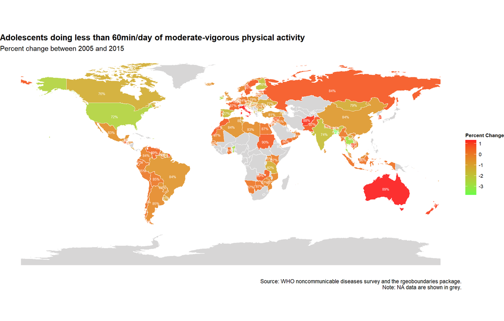

```r
world <- geoboundaries()


#loading NCD activity data
NCD_activity <- read_csv("NCD_PAC_ADO.csv")


#creating a change var between 2005 and 2015
#breaking out by year
ncd_05 <- NCD_activity %>%
  filter(TimeDim == 2005)%>%
  group_by(SpatialDimensionValueCode) %>%
  filter(DisaggregatingDimension1ValueCode == "BTSX")
ncd_15 <- NCD_activity %>%
  filter(TimeDim == 2015)%>%
  group_by(SpatialDimensionValueCode) %>%
  filter(DisaggregatingDimension1ValueCode == "BTSX")

#creating long form with only two years
ncd_long<- rbind(ncd_05, ncd_15)%>% select(TimeDim, SpatialDimensionValueCode, NumericValue)

#pivoting to wide
ncd_wide <- pivot_wider(ncd_long, names_from = TimeDim, values_from = NumericValue) %>%
  rename(
    "value_05" = "2005",
    "value_15" = "2015"
  )

#adding change over time column
ncd_wide <- ncd_wide %>% mutate(Percent_change = (value_15 - value_05),
                                round_15 = round(value_15, digits=0),
                                round_15 = as.character(round_15),
                                round_15 = paste0(round_15, "%"))

#joining to world spatial data
ncd_geo_wide <- world %>% left_join(ncd_wide,
                                    by = c("shapeISO" = "SpatialDimensionValueCode"),
                                    copy = FALSE,
                                    suffix = c(".x",".y"),
                                    keep = TRUE)


#creating map of change over time
ncd_geo_wide%>%
  ggplot()+
  geom_sf(aes(fill = Percent_change, color= na), color = "white", alpha = 0.9)+
  scale_fill_gradient(
    low = "#67FC4A",
    high = "#FC1A1A",
    na.value = "#D3D2D2",
  )+

  scale_color_manual(breaks=c("TRUE"),values = "#D3D2D2", labels = 'Data not available')+

  geom_sf_text(aes(label = round_15), color = "white", size = 2)+

  theme_void()+
  theme(plot.title = element_text(face = "bold"),
        legend.title = element_text(size = 8, face = "bold"),
        legend.text = element_text(size = 8)) +


  labs(
    title = "Adolescents doing less than 60min/day of moderate-vigorous physical activity",
    subtitle = "Percent change between 2005 and 2015",
    fill = "Percent Change",
    caption = str_wrap("Source: WHO noncommunicable diseases survey and the rgeoboundaries package. Note: NA data are shown in grey.")
  )
```

*Interpretation*

The above map shows trends in activity levels of adolescents from 2005 to 2015. While much of the world’s teens changed little over this time period, teens in the United States, India, and Canada trended closer to meeting the World Health Organization’s recommended 60 minutes of moderate to high intensity activity per day. Overlaying the color map of the world are the rounded 2015 values of each country teens in relation to WHO standards.

Data to create this visualization come from the World Health Organization and the rgeoboundaries package.

## Visualization 3: Bar Graph of Alcohol Consumption between Males and Females

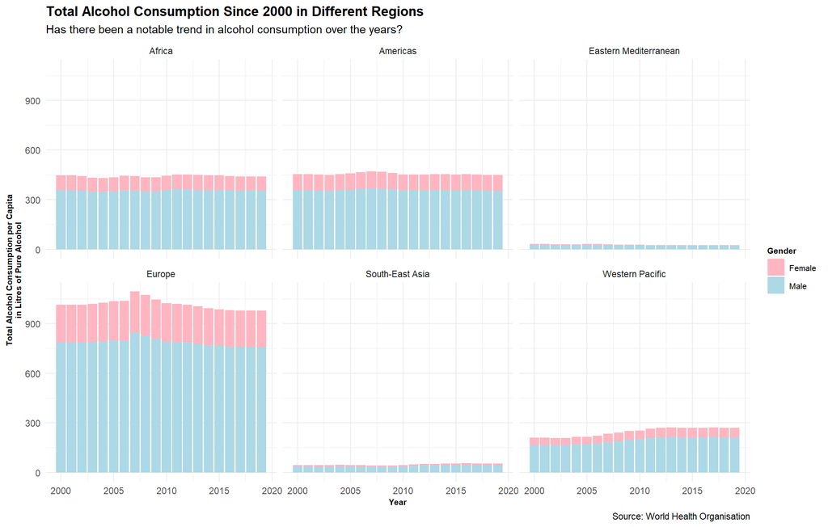

```r
# import alcohol dataset
alcohol <- read_csv("alcohol.csv")

# select data that is needed and make adjustments
alcohol2 <- alcohol %>%
  select(Location, Period, Dim1, FactValueNumeric, FactValueNumericLow, FactValueNumericHigh, ParentLocation) %>%
  rename("country" = Location,
         "year" = Period,
         "average" = FactValueNumeric,
         "min" = FactValueNumericLow,
         "max" = FactValueNumericHigh,
         "sex" = Dim1,
         "region" = ParentLocation) %>%
  filter(sex != "Both sexes")

# plot graph
alcohol2 %>%
  ggplot(aes(x = year,
             y = average)) +
  geom_col(aes(fill = sex)) +

  facet_wrap(~region) +

  # add the labels
  labs(x = "Year",
       y = "Total Alcohol Consumption per Capita\nin Litres of Pure Alcohol",
       caption = "Source: World Health Organisation",
       title = "Total Alcohol Consumption Since 2000 in Different Regions",
       subtitle = "Has there been a notable trend in alcohol consumption over the years?",
       fill = "Gender"
  ) +

  theme_minimal() +
  theme(plot.title = element_text(face = "bold"),
        axis.title = element_text(size = 8, face = "bold"),
        legend.title = element_text(size = 8, face = "bold"),
        legend.text = element_text(size = 8)) +

  scale_fill_manual(values = c("lightpink", "lightblue"))
```

*Interpretation*

This visualization tracks alcohol consumption trends in different regions around the world between males and females. The theory is that alcohol consumption has increased drastically in the past 10 years, however, the results proved otherwise. Alcohol consumption seems to be somewhat consistent since 2000, with males consuming much more alcohol and females in all regions.

Data for used in this visualization came from the World Health Organization.

## Visualization 4: Pie chart of neonatal mortality causes

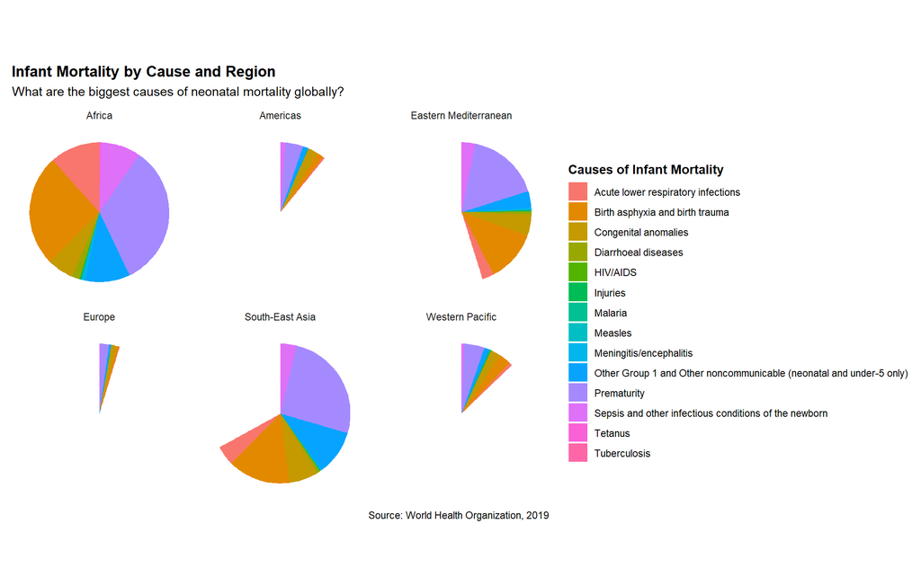

```r
#import mortality data
mortality <- read_excel("mortality.xlsx") %>% clean_names() %>% mutate(value_string = as.numeric(value_string))

###selecting only 2019 data, and only data from each region
mort_19 <- mortality %>% filter(year == 2019, who_region != "Global")

###defining a blank theme
blank_theme <- theme_minimal()+
  theme(
    axis.title.x = element_blank(),
    axis.title.y = element_blank(),
    panel.border = element_blank(),
    panel.grid = element_blank(),
    axis.ticks = element_blank(),
    plot.title = element_text(face ="bold"),
    legend.title = element_text(face = "bold")
  )


mort_19 %>% ggplot(mapping = aes(x = "" , y = value_string, fill = cause)) +
  geom_bar(width = 1, stat = "identity")+
  coord_polar("y", start= 0)+
  theme_minimal() +
  facet_wrap(~who_region)+ blank_theme +
  theme(axis.text.x=element_blank()) +
  labs(title = "Infant Mortality by Cause and Region",
       subtitle = "What are the biggest causes of neonatal mortality globally?",
       caption = "Source: World Health Organization, 2019",
       fill = "Causes of Infant Mortality")
```

*Interpretation*

This is a quick snapshot of what leading causes of infant mortality are across the world. As is evident by these side-by side comparisons, the Americas, Europe and the Western Pacific experience relatively fewer infant mortalities overall compared to Africa and South East Asia.

Data for this visualization come from the World Health Organization.